# LM_IR_Proteomics

Geremy Clair

March 1, 2021

# 1 Required library

The required libraries are loaded - RomicsProcessor written by Geremy Clair (2022, in prep.) is used to perform traceable transformation and statistics to the dataset.

```r
library("RomicsProcessor")
```

# 2 MaxQuant import

The LFQ data contained in the protein table was loaded, the corresponding metadata was loaded

```r
data<-extractMaxQuant("~/Documents/05 - Lungmap/36 - LM_IR/01_source_files/proteinGroups.txt",quantification_type = "LFQ",cont.rm = T,site.rm = T,rev.rm = T)
```

```
## [1] "100  Proteins were removed (protein(s) only identified by site,contaminant(s),reverse hit(s))"
## [1] "LFQ quantification was used"
```

```r
data[,1]<-gsub("\\;.*","",data[,1])
data[,1]<-gsub(".*\\|","",data[,1])
representative_ID <- data[,1]

IDsdetails<-cbind(Identifiers=representative_ID, extractMaxQuantIDs("./01_source_files/proteinGroups.txt",cont.rm = T,site.rm = T,rev.rm = T))
```

```
## [1] "100  Proteins were removed (protein(s) only identified by site,contaminant(s),reverse hit(s))"
```

```r
metadata<- read.csv(file = "./01_source_files/metadata.csv")
write.csv(extractMaxQuantIDs("./01_source_files/proteinGroups.txt",cont.rm = T,site.rm = T,rev.rm = T),"./03_output_files/MaxQuantIDS.csv")
```

```
## [1] "100  Proteins were removed (protein(s) only identified by site,contaminant(s),reverse hit(s))"
```

# 3 Romics_object creation

The data and metadata were placed in an romics_object, the sample names were retrieved from the metadata, the condition will be use for the coloring of the Figure and statistics

```r
romics_proteins<- romicsCreateObject(data,metadata,main_factor = "Condition")
```

# 4 Full data analysis

## 4.1 Data cleaning and normalization

The missingness was evaluated for each channel/sample

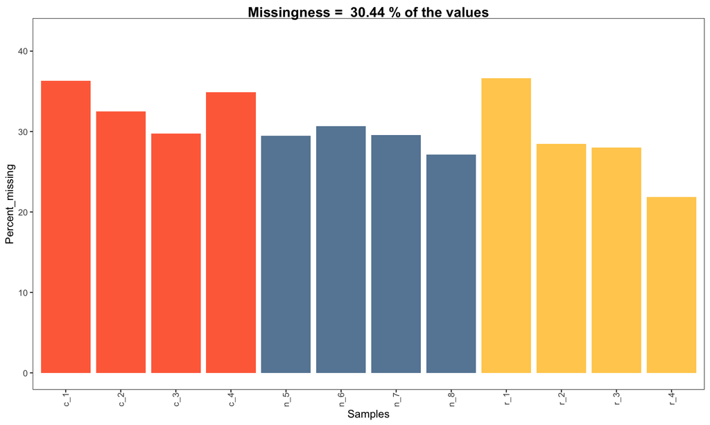

```r
romics_proteins<- romicsZeroToMissing(romics_proteins)
romicsPlotMissing(romics_proteins)
```

The data was log2 transformed, the distriution boxplot were then plotted

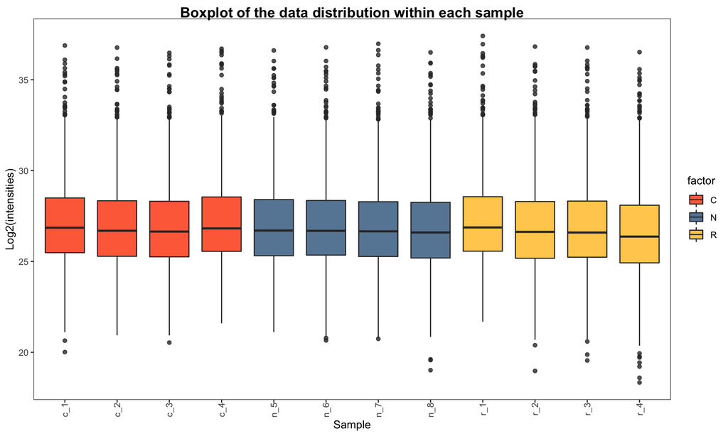

```r
romics_proteins<-log2transform(romics_proteins)
distribBoxplot(romics_proteins)
```

```r
romics_proteins<-romicsFilterMissing(romics_proteins,percentage_completeness = 60)
```

```
## [1] "788 rows were removed for the data"
## [1] "Based on the minimum completeness set at 60%"
## [1] "at least the following number of sample(s) containing data was required:"
## C N R
## 3 3 3
## [1] "2024/2812 features remained after filtering (71.98%)."
```

```r
print(paste0(nrow(romics_proteins$data),"/", nrow(romics_proteins$original_data)," proteins remained after filtering", " (",round(nrow(romics_proteins$data)/nrow(romics_proteins$original_data)*100,2),"%)."))
```

```
## [1] "2024/2812 proteins remained after filtering (71.98%)."
```

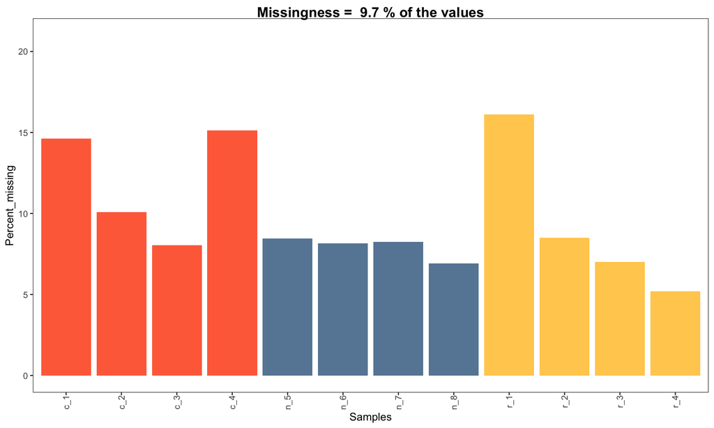

```r
romicsPlotMissing(romics_proteins)
```

As the same quantity of protein was labelled for each sample, the expectation is that the distribution of the protein abundance is centered, therefore a median centering was performed prior to plot again the distribution boxplots.

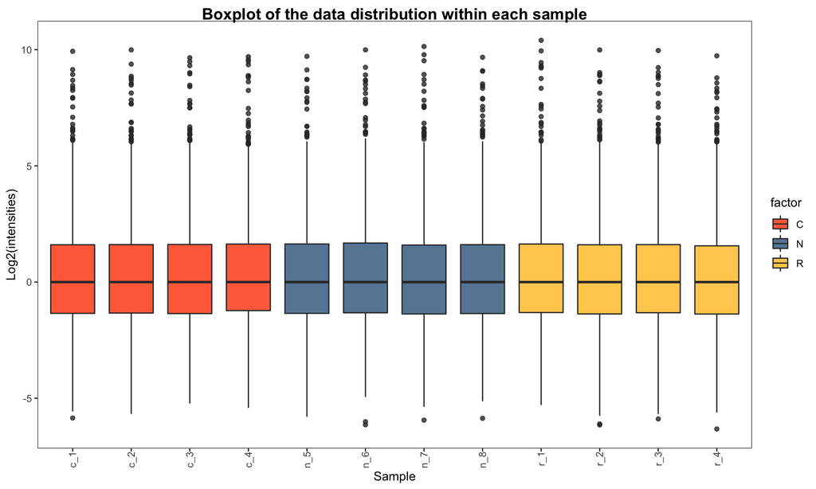

```r
romics_proteins<-medianCenterSample(romics_proteins)
distribBoxplot(romics_proteins)
```

## 4.2 Data imputation

For some of the subsequent statistics imputations are required, we performed an imputation by assuming that the “non-detected” proteins were either low abundance or missing using the method developped by Tyranova et al. (PMID: 27348712). The gray distribution is the data distribution, the yellow distribution is the one for the random values used for imputation.

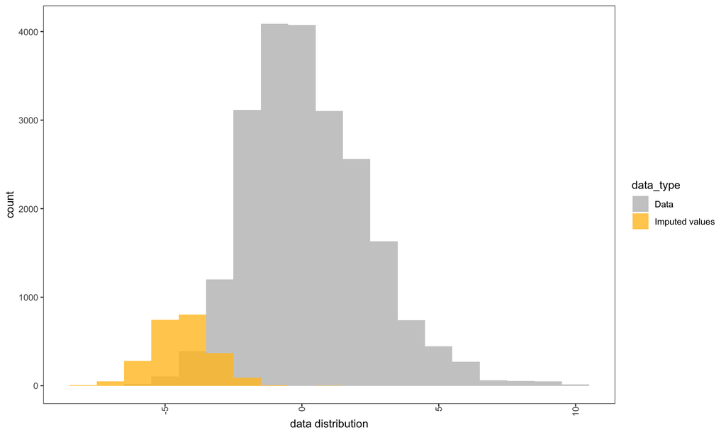

```r
imputeMissingEval(romics_proteins,nb_stdev = 2,width_stdev = 0.5, bin=1)
```

```r
romics_proteins<-imputeMissing(romics_proteins,nb_stdev = 2,width_stdev = 0.5)
```

## 4.3 Statistics

The means and stdev are calculated for each group

```r
romics_proteins<-romicsMean(romics_proteins)
```

```
## [1] "The Statistics layer was added to your object"
## [1] "Means columns (*_mean) were added to the statistics"
```

```r
romics_proteins<-romicsSd(romics_proteins)
```

```
## [1] "The standard deviation columns (*_sd) were added to the statistics"
```

ANOVA are performed

```r
romics_proteins<-romicsANOVA(romics_proteins)
```

```
## [1] "The ANOVA columns (ANOVA_p and ANOVA_padj) were added to the statistics"
```

A heatmap depicting the proteins passing an ANOVA p<0.05 is plotted, the clusters obtained were saved in the statistics.

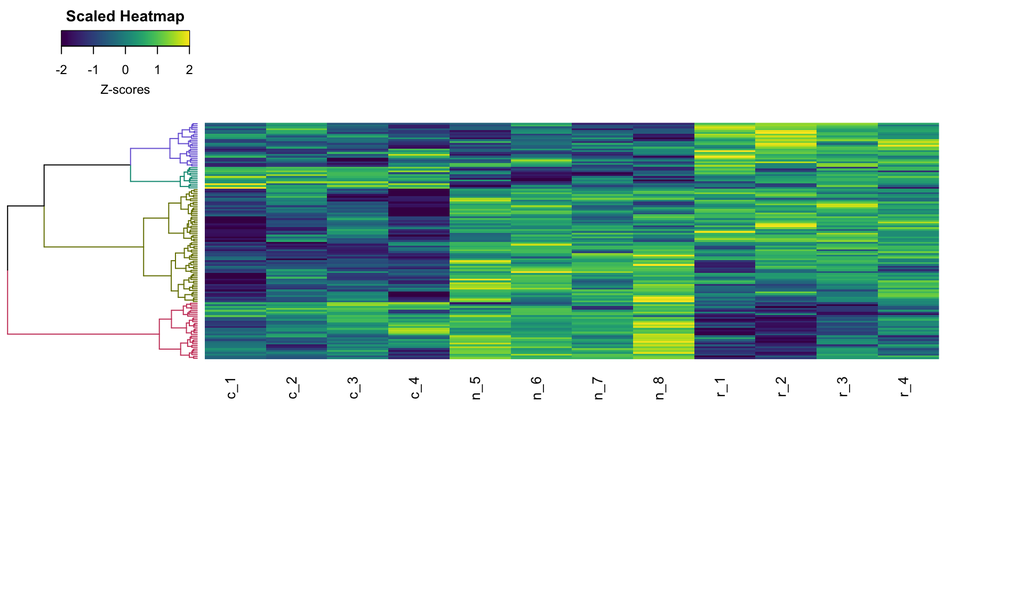

```r
romicsHeatmap(romics_proteins,variable_hclust_number = 4,ANOVA_filter = "p", p=0.05,sample_hclust = F)
```

```r
romics_proteins<-romicsVariableHclust(romics_proteins,clusters = 4,ANOVA_filter = "p",p= 0.05,plot = F)
```

```
## [1] "The columns hclust_clusters was added to the statistics"
```

```r
romics_proteins<-romicsZscores(romics_proteins)
```

```
## [1] "Z_score_ columns were added to the statistics"
```

T.tests were added to the statistics

```r
romics_proteins<-romicsTtest(romics_proteins,percentage_completeness = 60)
```

```
## [1] "T_test columns were added to the statistics"
```

```r
romicsVolcano(romics_proteins,p_type = "p",min_fold_change = 0)
```

```
## [1] "'stat_type' was missing 't.test' were used by default"
```

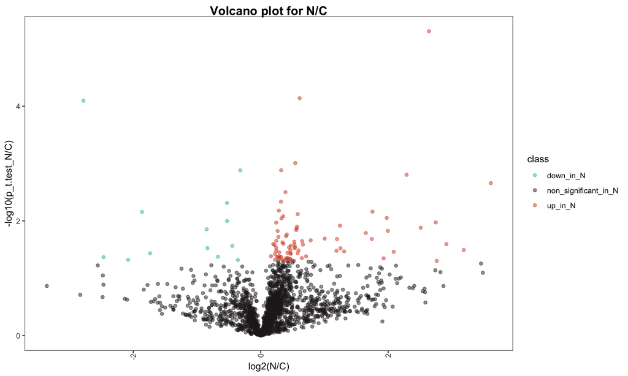

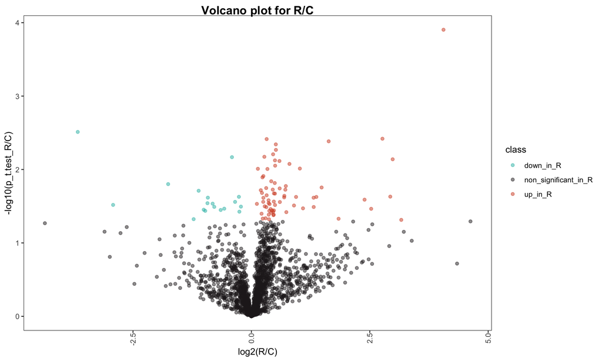

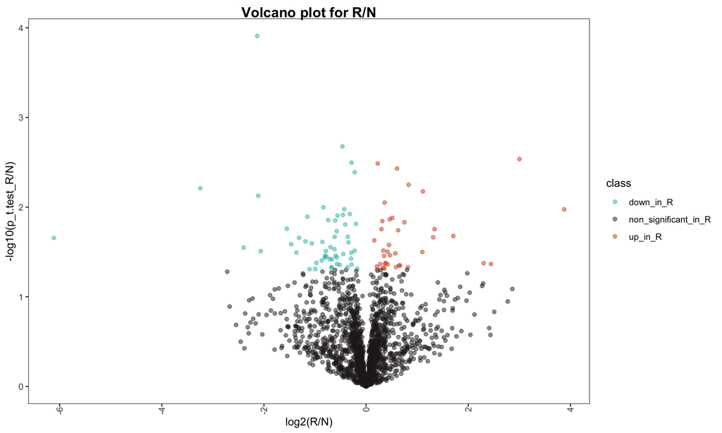

The data was exported for further exploration and to generate supplementary dataset files.

```r
results<-romicsExportData(romics_proteins,statistics = T,missing_data = T)
results<-cbind(Identifiers = rownames(results), results)
results<-merge(results,IDsdetails,by= "Identifiers")
write.csv(results, file= "./03_output_files/Data_processed_with_stats.csv")
save(romics_proteins,file = "03_output_files/romics_proteins.rda")
```